# fabOF Test Report — After Dependency Changes

## 8. plot_pdp

```r
library(ggplot2)
library(dplyr)
set.seed(123)
result_cont <- plot_pdp(
  data = test_data, model = test_mixfabof, response = "y",
  x_var = "x1", x_var_title = "X1", nmax = 50, nIce = 10,
  verbose = TRUE, borders = "none"
)
cat("variable_type:", result_cont$variable_type, "\n")
```

```
variable_type: continuous
```

```r
cat("ice_data nrow:", nrow(result_cont$data$ice_data), "\n")
```

```
ice_data nrow: 500
```

```r
cat("pdp_data nrow:", nrow(result_cont$data$pdp_data), "\n")
```

```
pdp_data nrow: 10
```

```r
cat("pdp_data fit values:\n")
```

```
pdp_data fit values:
```

```r
print(round(result_cont$data$pdp_data$fit, 8))
```

```
 [1] 2.040855 1.960637 2.117163 2.077160 1.992013 2.066590 1.921254 2.125636
 [9] 2.111569 2.272186
```

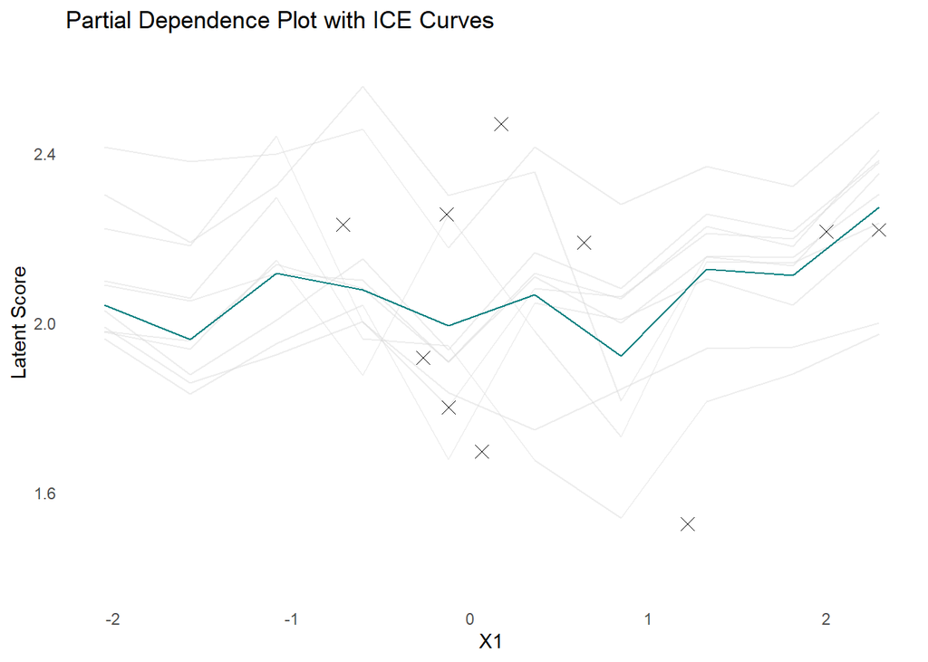

```r
result_cont$plot
```

```r
set.seed(123)
result_cat <- plot_pdp(
  data = test_data, model = test_mixfabof, response = "y",
  x_var = "x3", x_var_title = "X3", nmax = 50, nIce = 10,
  verbose = TRUE, borders = "none"
)
cat("variable_type:", result_cat$variable_type, "\n")
```

```
variable_type: categorical
```

```r
cat("ice_data nrow:", nrow(result_cat$data$ice_data), "\n")
```

```
ice_data nrow: 150
```

```r
cat("pdp_data nrow:", nrow(result_cat$data$pdp_data), "\n")
```

```
pdp_data nrow: 3
```

```r
cat("pdp_data fit values:\n")
```

```
pdp_data fit values:
```

```r
print(round(result_cat$data$pdp_data$fit, 8))
```

```
[1] 2.123542 2.015065 1.971259
```

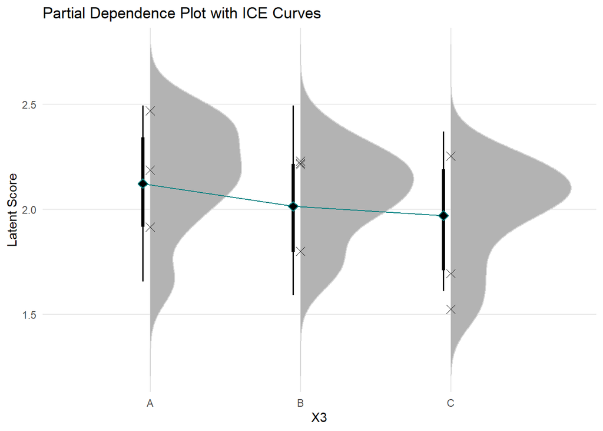

```r
result_cat$plot
```